# maleque

2024-02-14

# Introdução

• Objetivo: Investigar a relação entre a eficiência operacional das empresas e a gestão de seus ativos e dívidas. Este tema focará em entender como a gestão de custos, ativos e dívidas influencia a lucratividade e a saúde financeira da empresa. Identificar padrões ou tendências entre diferentes segmentos de mercado e localizações geográficas.

# Análise Estatística Descritiva

## Colunas Quantitativas

| Variável | Tipo_de_Dados |
| --- | --- |
| Id | Numérico |
| Revenue | Numérico |
| Cost | Numérico |
| Profit | Numérico |
| Employees | Numérico |
| Debt | Numérico |
| Assets | Numérico |
| Equity | Numérico |
| R_D | Numérico |
| Customer_Satisfaction | Numérico |
| Employee_Satisfaction | Numérico |
| Growth_Rate | Numérico |
| Innovation_Score | Numérico |

## Colunas Qualitativas

| Variável | Tipo_de_Dados |
| --- | --- |
| Market | Texto |
| Location | Texto |

## Histograma Quantitativas

```r
# Histogramas para variáveis quantitativas
histogramas <- lapply(variaveis_quantitativas, function(variavel) {
  ggplot(dados, aes_string(x = variavel)) +
    geom_histogram(fill = "purple", color = "black", bins = 50) +
    labs(title = paste("Histograma de", variavel),
         x = variavel,
         y = "Frequência") +
    theme_minimal()
})
# Gráficos de frequência para variáveis qualitativas
graficos_qualitativos <- lapply(variaveis_qualitativas, function(variavel) {
  ggplot(dados, aes_string(x = `variavel`)) +
    geom_bar(fill = "purple", color = "black") +
    labs(title = paste("Gráfico de Frequência de", variavel),
         x = variavel,
         y = "Frequência") +
    theme_minimal()
})

# Imprimir os histogramas
print("Histogramas para Variáveis Quantitativas:")
```

```
## [1] "Histogramas para Variáveis Quantitativas:"
```

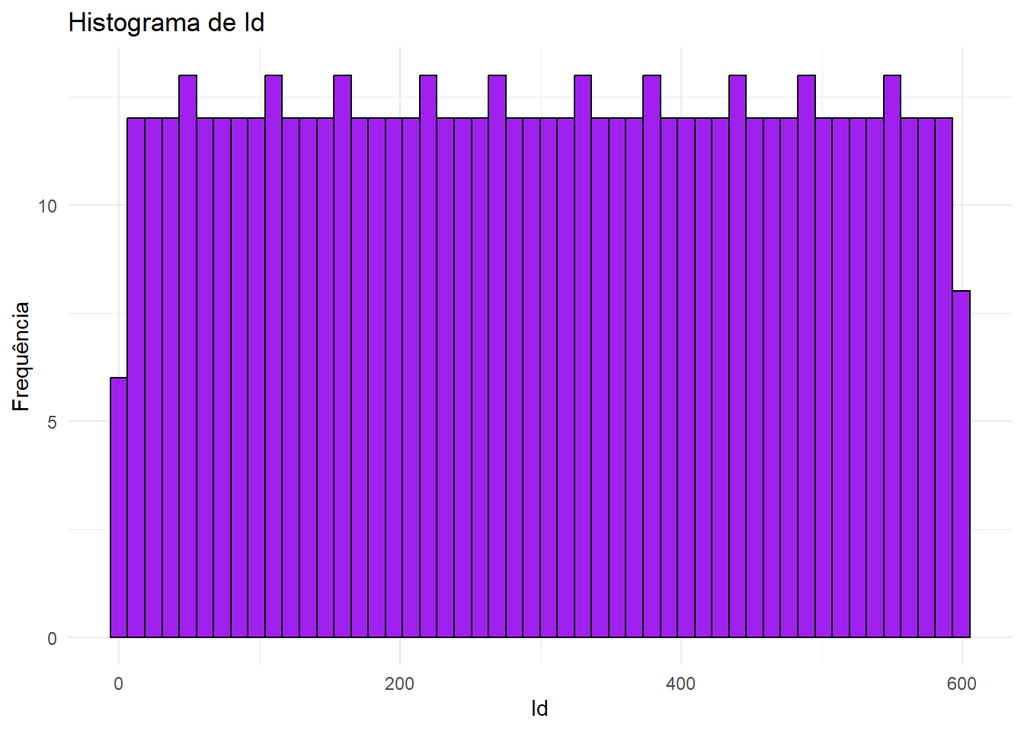

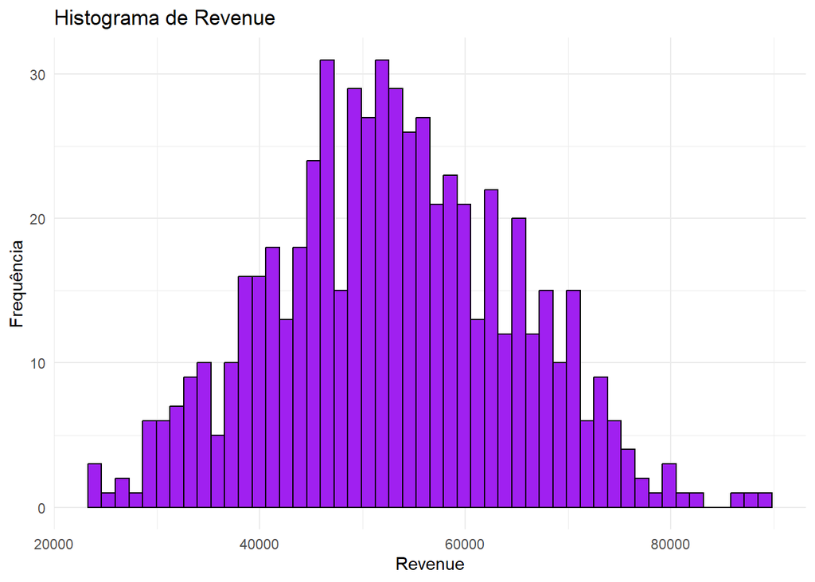

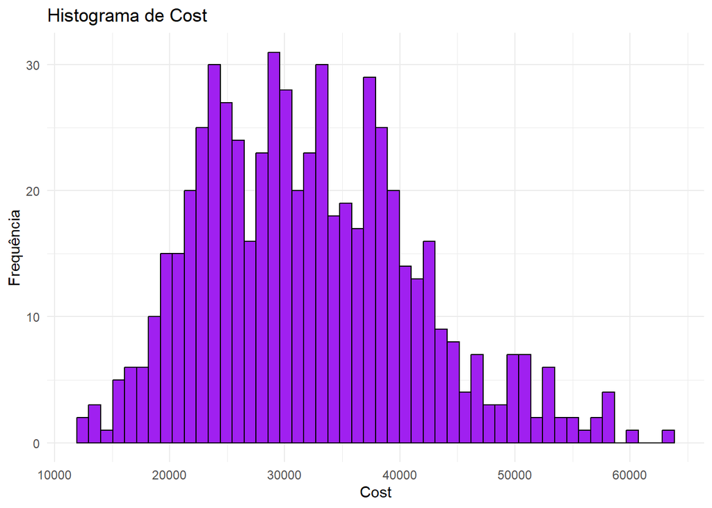

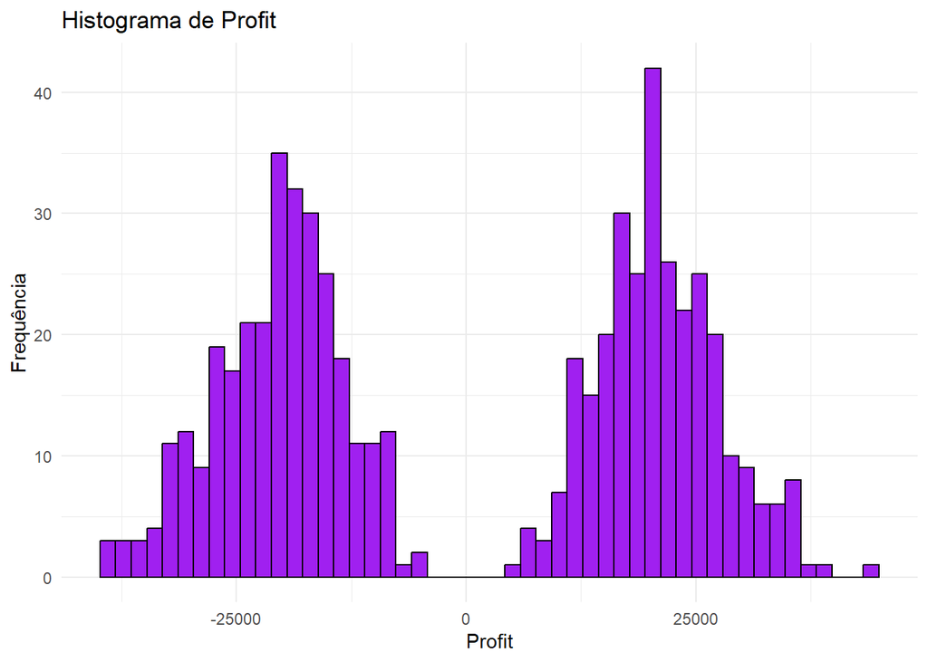

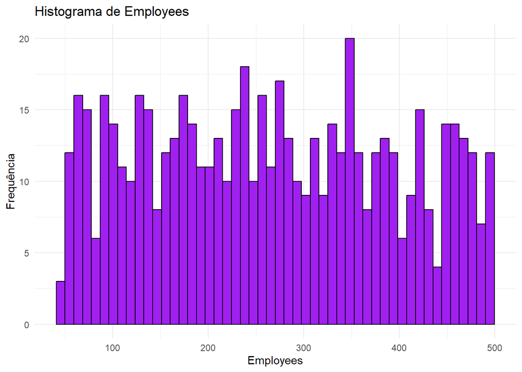

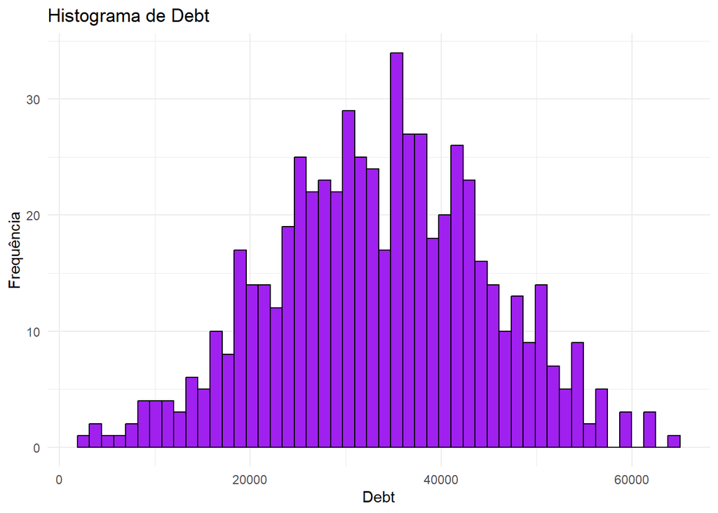

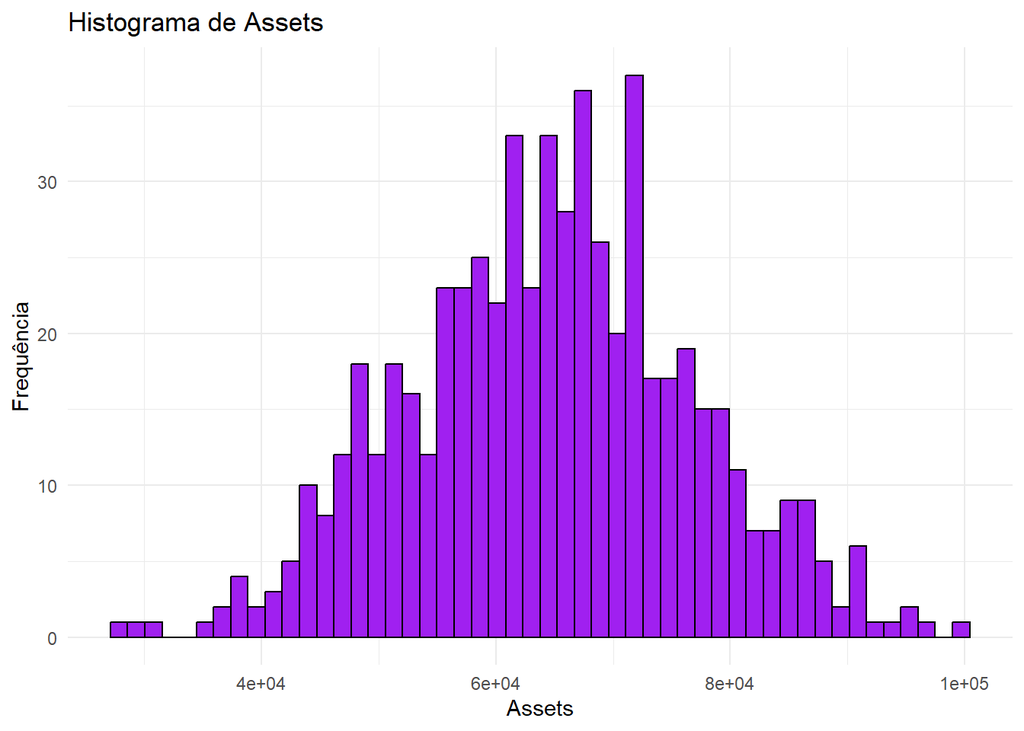

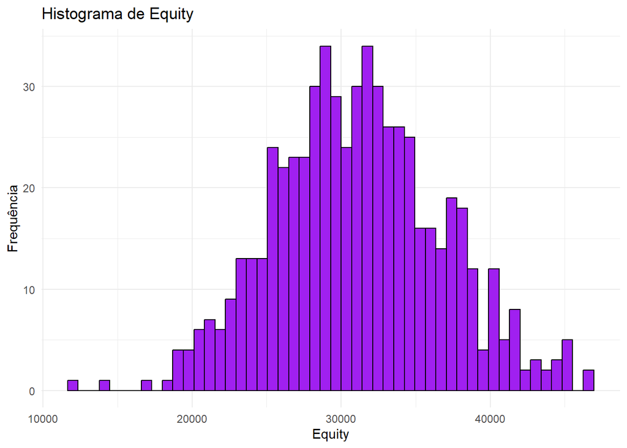

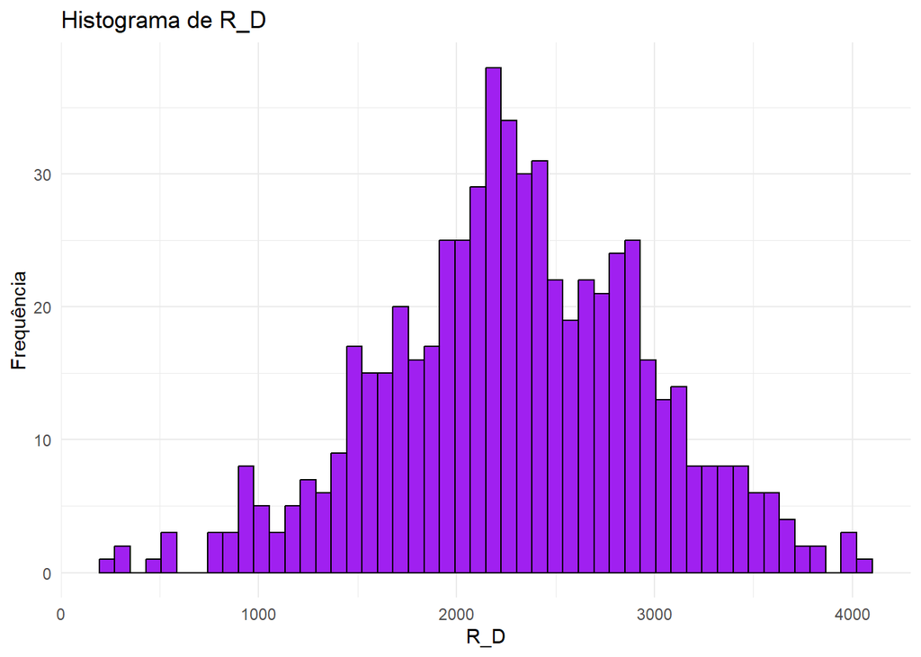

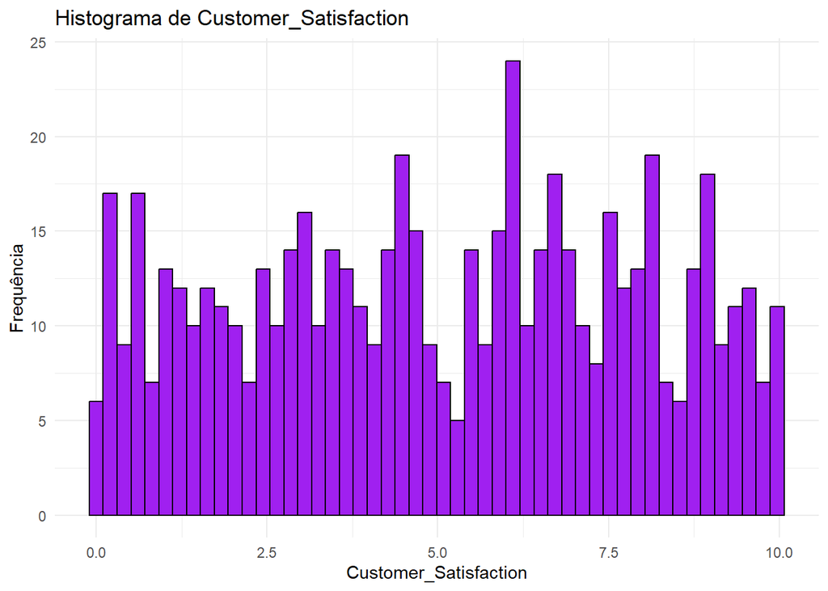

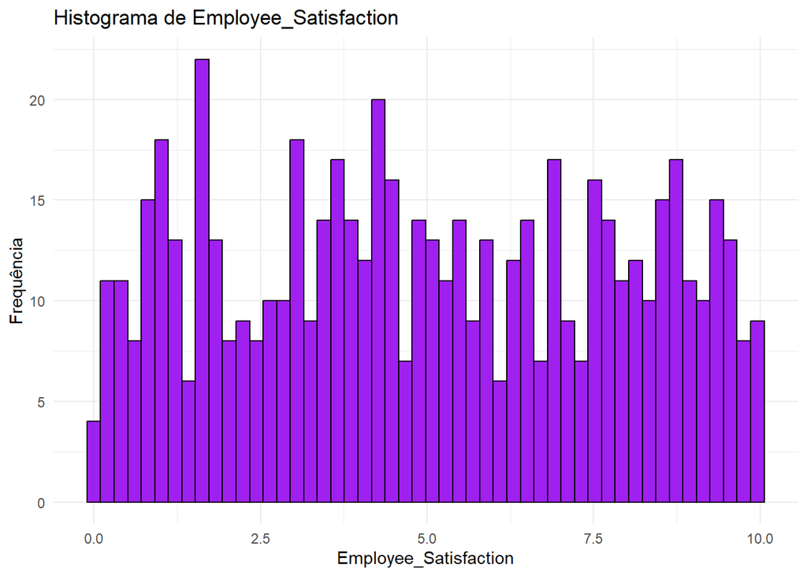

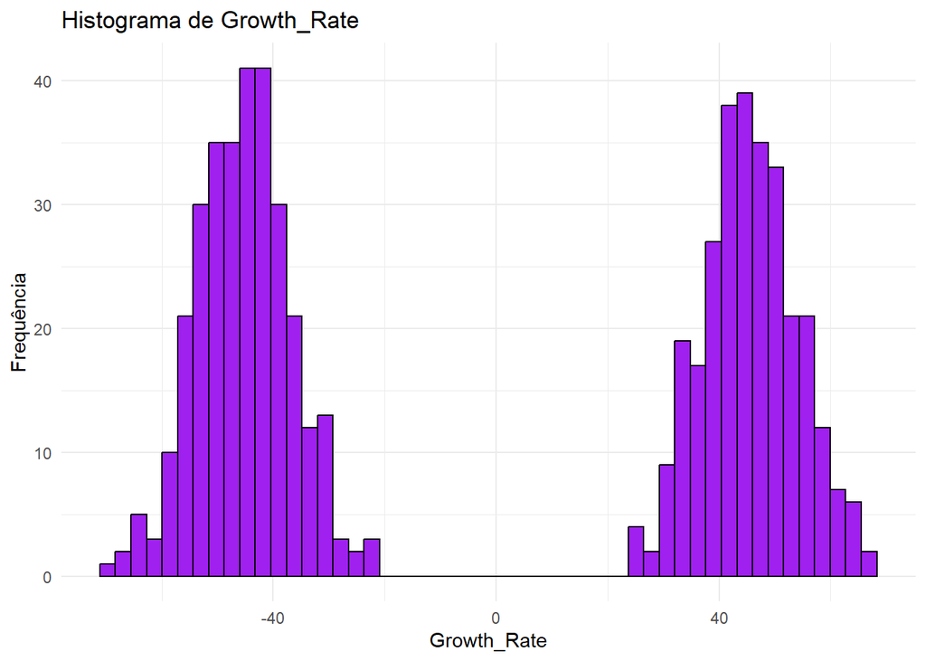

[1 more figures not shown]

```r
print(histogramas)
```

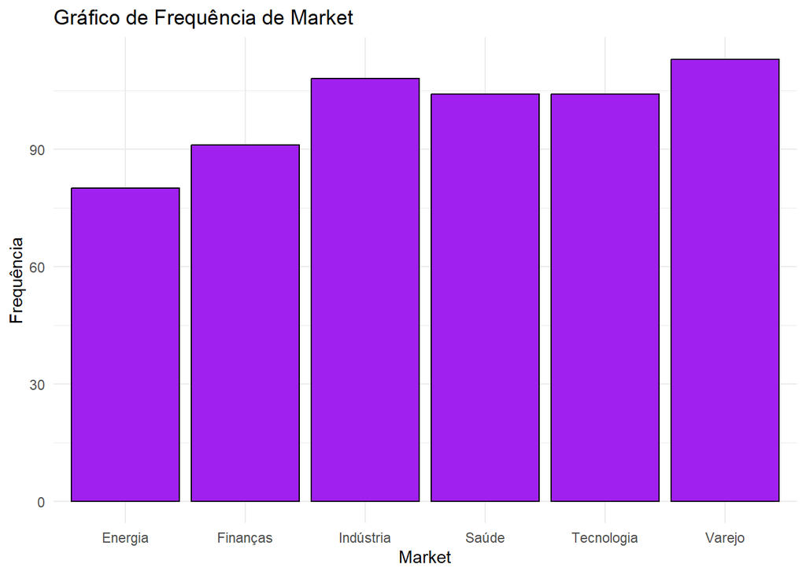

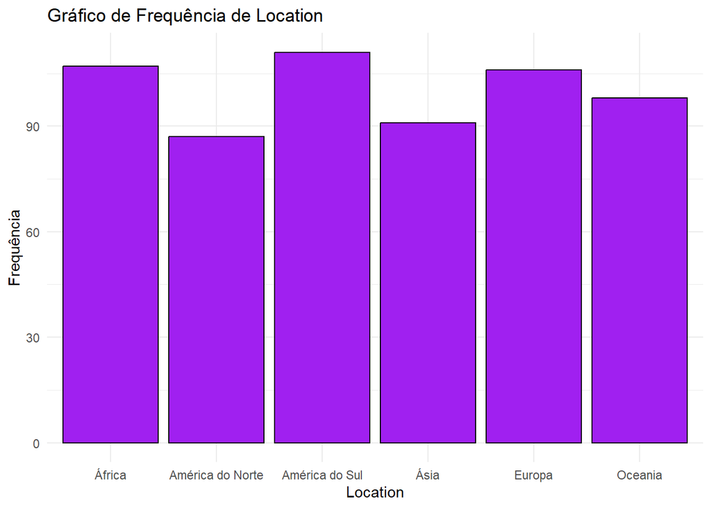

```r
#
# # Imprimir os gráficos de frequência
# print("Gráficos de Frequência para Variáveis Qualitativas:")
print(graficos_qualitativos)
```

## Outliers com Box-Plots

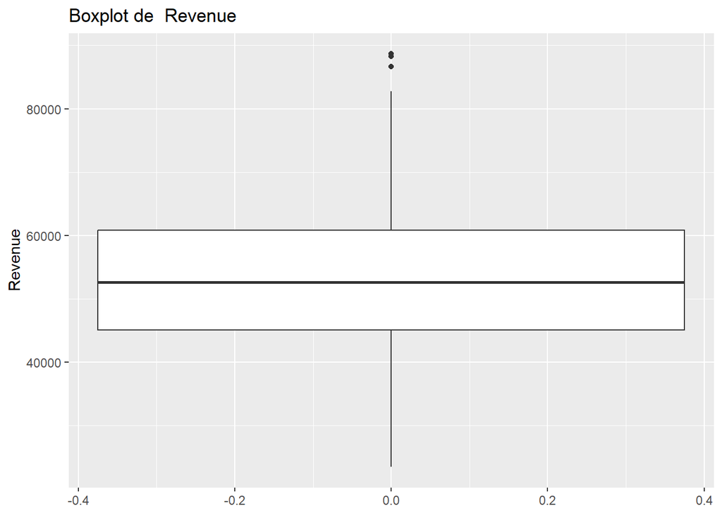

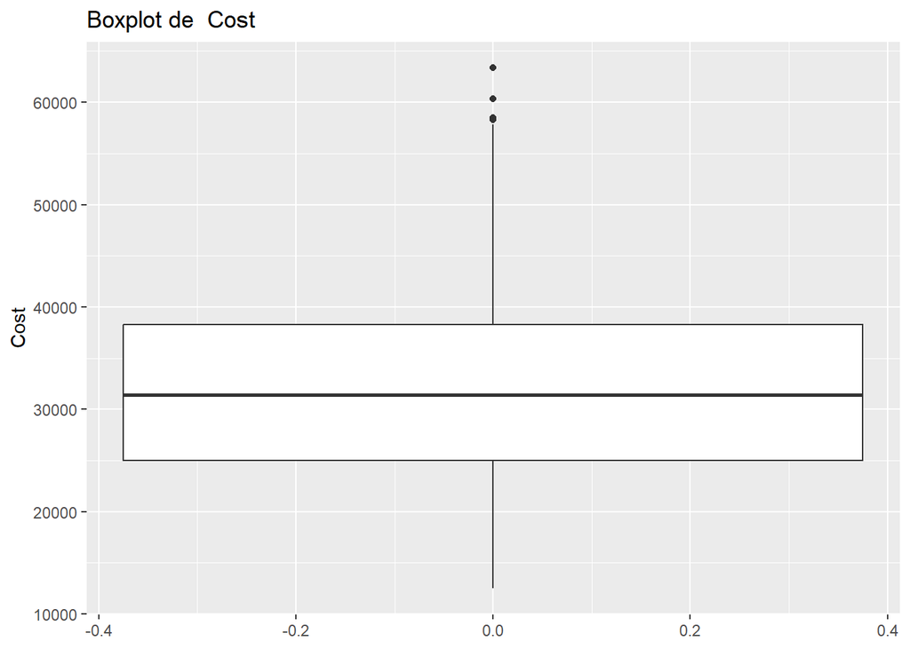

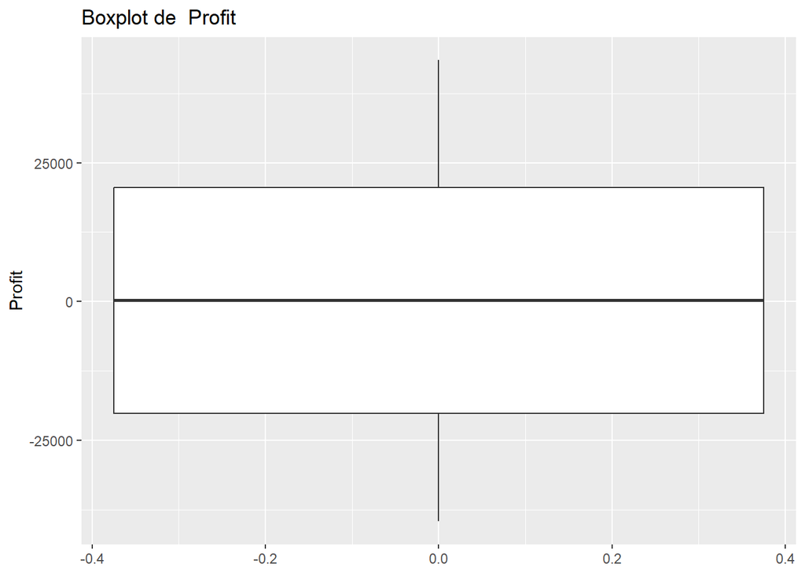

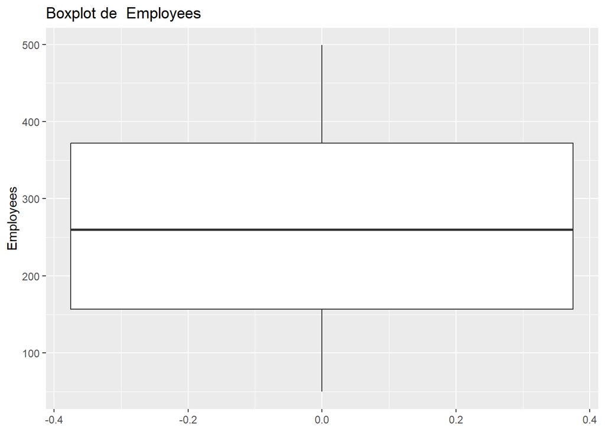

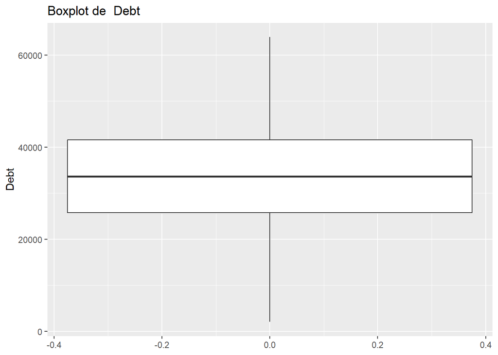

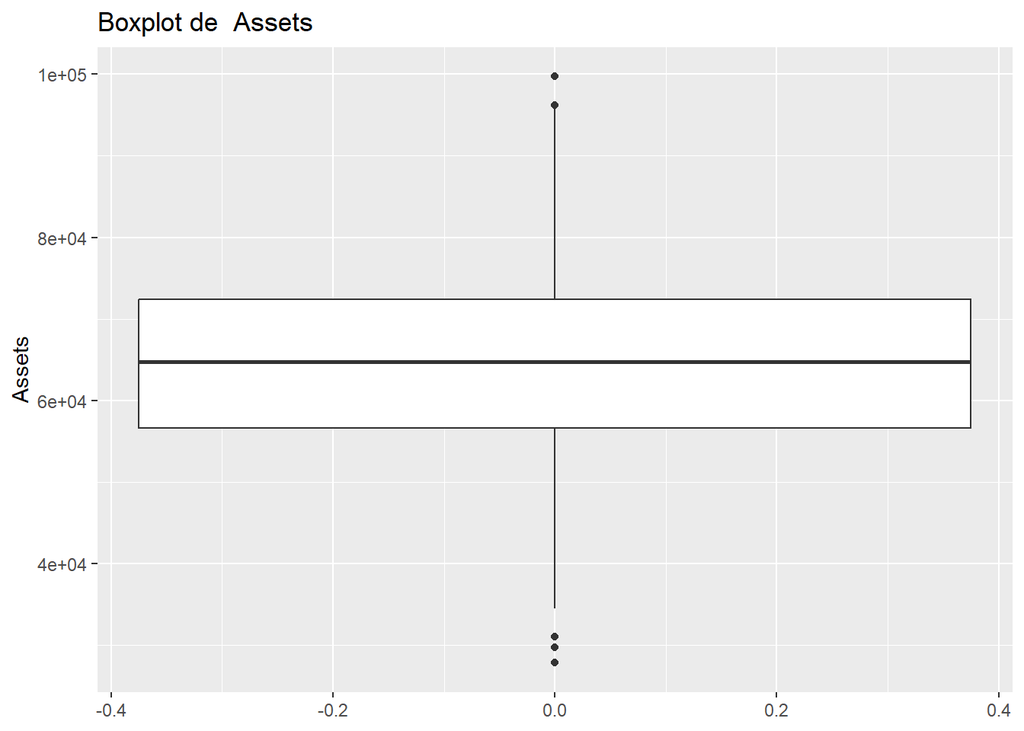

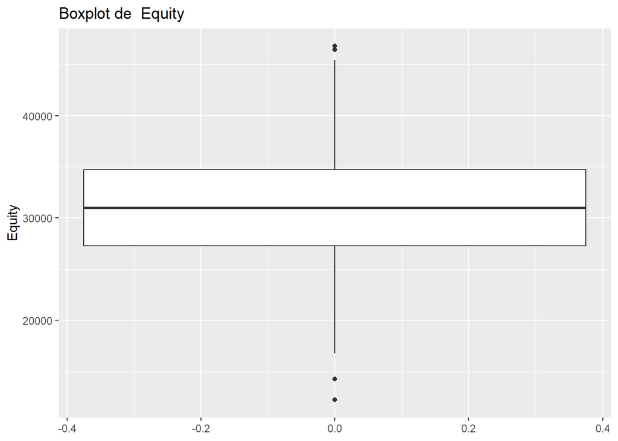

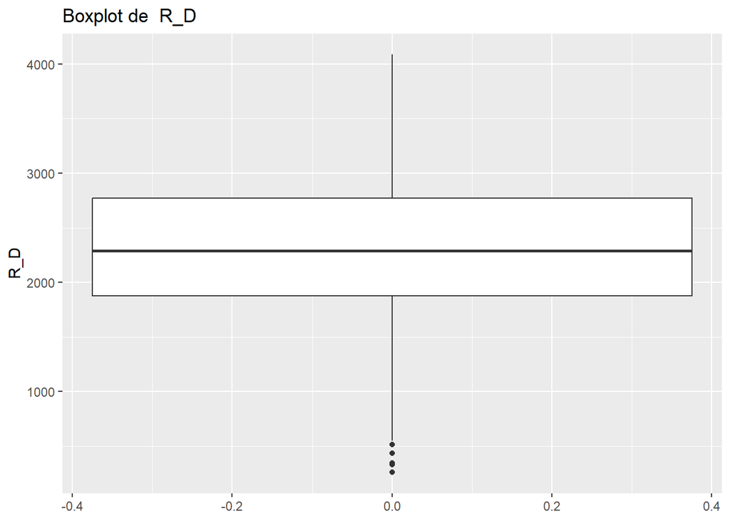

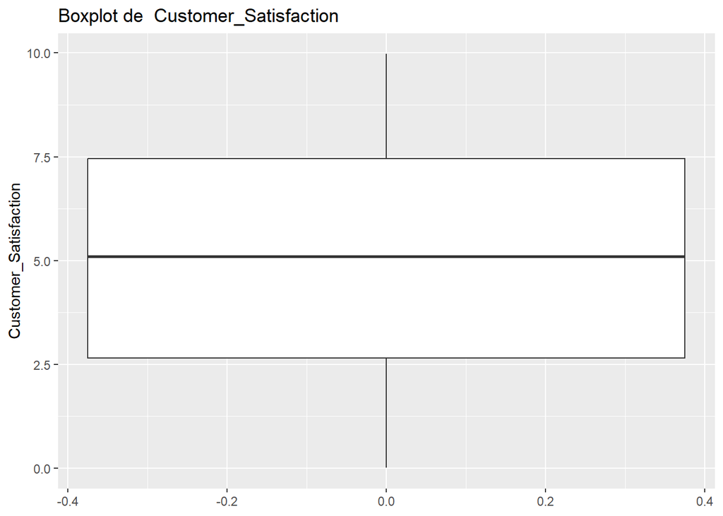

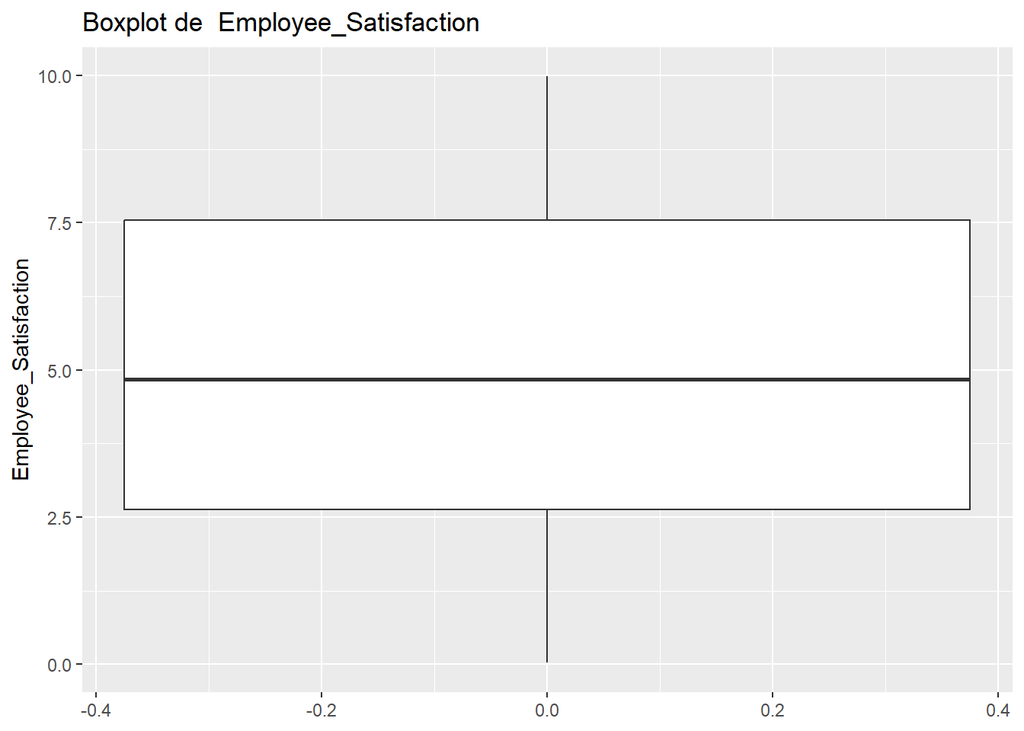

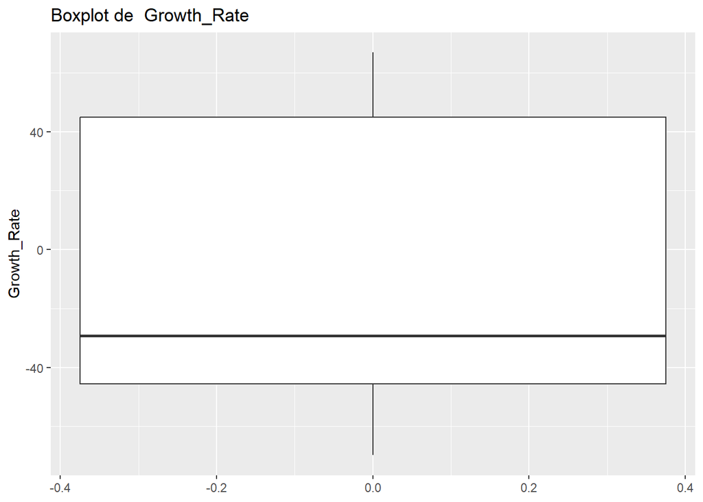

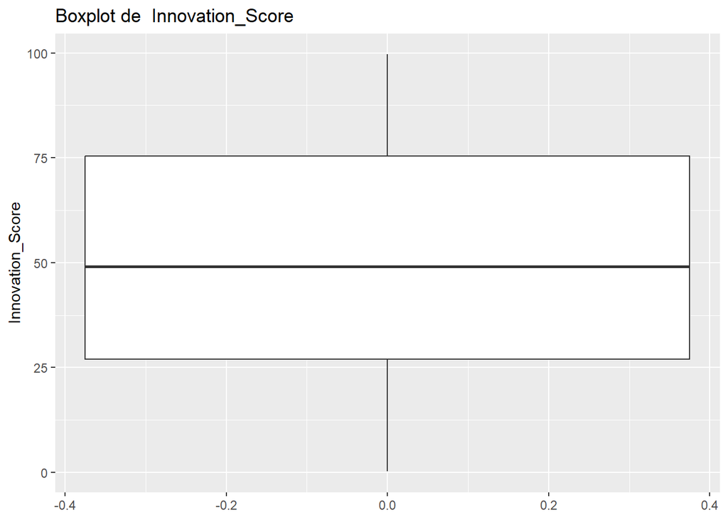

```r
plot_box = function(variavel){
ggplot(dados, aes_string(y= variavel))+
  geom_boxplot()+
    labs(
      title=paste("Boxplot de ", variavel),
      y = variavel
    )
}

lapply(variaveis_quantitativas[variaveis_quantitativas != "Id"] , plot_box)
```

# Análise das relações

Etatísticas básicas

## Correlação entre variáveis-chave

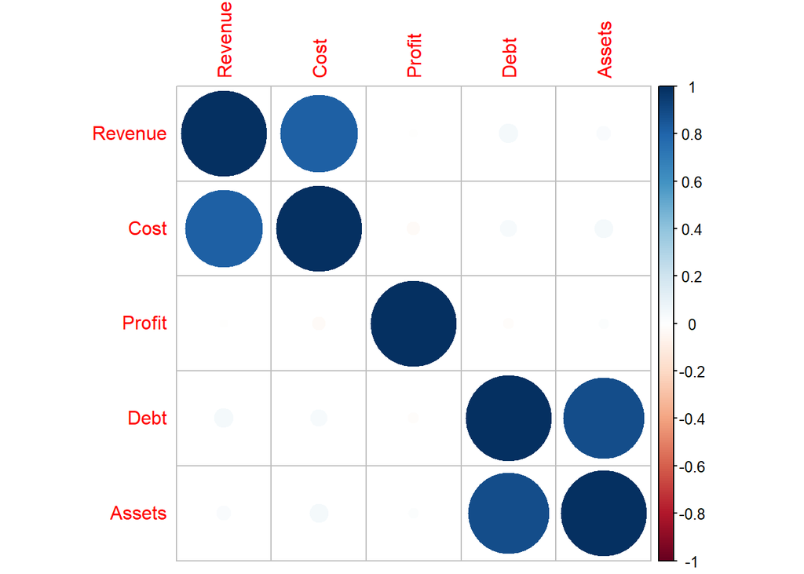

```r
correlation_matrix <- cor(dados[c("Revenue", "Cost", "Profit", "Debt", "Assets")])
corrplot(correlation_matrix, method = "circle")
```

Custo tem correlação positiva com Receita, ou seja, quanto mais investe mais receita obtém.

E Ativos tem correlação positiva com Dívida, ou seja, quanto mais caro o ativo, mais dívida o investidor terá.

## Investigando Lucro

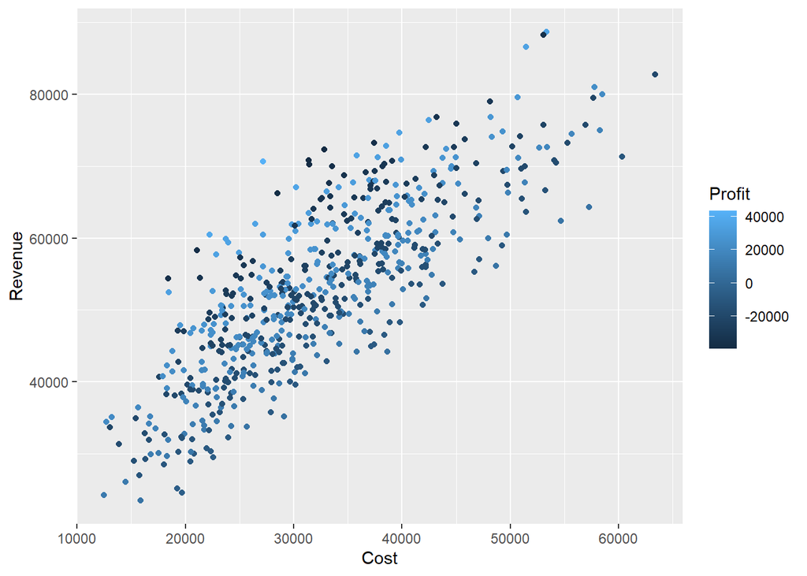

Pode se ver pelo grafico abaixo, que quanto maior o custo, maior sera a receita, mas isso não necessariamente significa que haverá Lucro.

## Relação entre Ativos e Dívidas e sua Influência na Lucratividade:

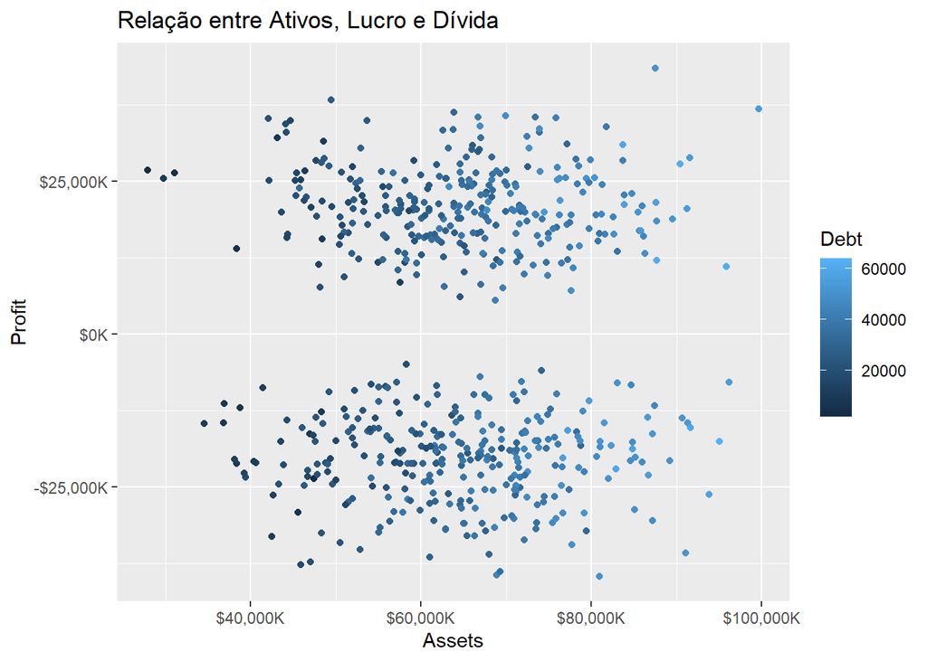

```r
ggplot(dados, aes(x = Assets, y = Profit, color = Debt)) +
  geom_point() +
  scale_x_continuous(labels = scales::dollar_format(suffix = "K")) +
  scale_y_continuous(labels = scales::dollar_format(suffix = "K")) +
  labs(title = "Relação entre Ativos, Lucro e Dívida")
```

Ativos de alto custo trazem divida maior para o investidor

## Melhores segmentos de mercado

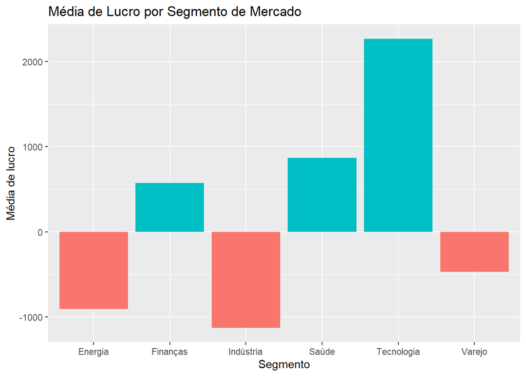

```r
segment_analysis = dados %>%
  group_by(Market) %>%
  summarise(
    mean_profit = mean(Profit)
  )
ggplot(segment_analysis, aes(x = Market, y = mean_profit, fill = mean_profit > 0)) +
  geom_bar(stat = "identity", show.legend = FALSE) +
  labs(title = "Média de Lucro por Segmento de Mercado",
       x = 'Segmento', y = 'Média de lucro')
```

Tecnologia é um ótimo segmento para investir

## Melhor região para investir

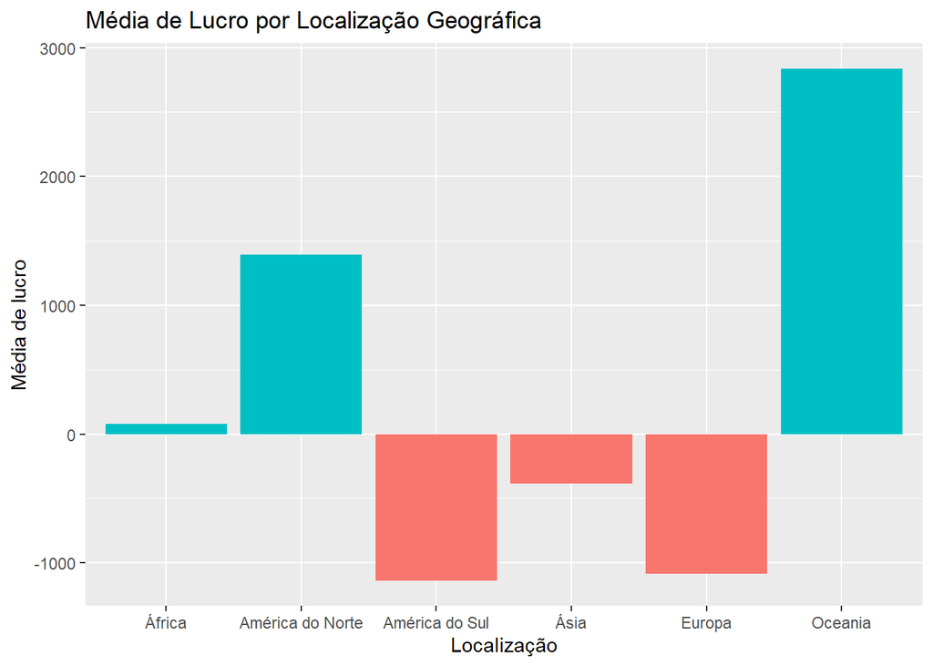

```r
location_analysis = dados %>%
  group_by(Location) %>%
  summarise(
    mean_profit = mean(Profit)
  )

ggplot(location_analysis, aes(x = Location, y = mean_profit, fill = mean_profit > 0)) +
  geom_bar(stat = "identity", show.legend=F) +
  labs(title = "Média de Lucro por Localização Geográfica", x = 'Localização',
       y = 'Média de lucro')
```

Oceania é um ótimo lugar para investir, seguido por America do Norte

### Localização nao é um indicativo de lucro, não há um padrão evidente para localização.

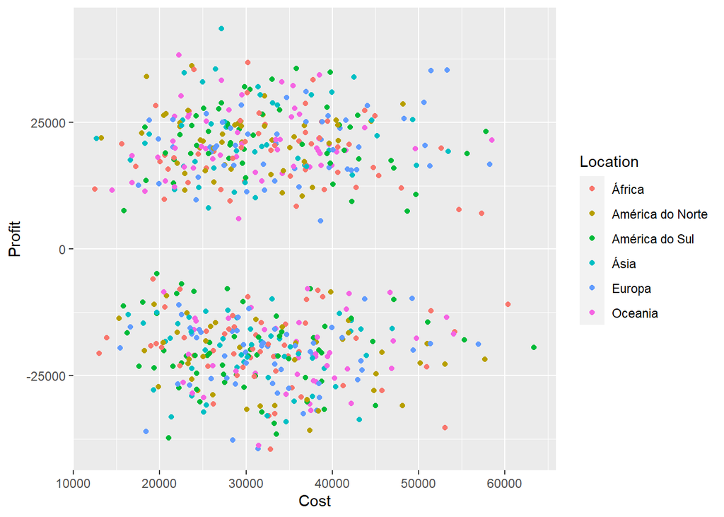

```r
dados  %>% ggplot(aes(Cost, Profit, color=Location))+
  geom_point()
```

### Mercado nao é um indicativo de lucro, não há um padrão evidente para segmento de mercado

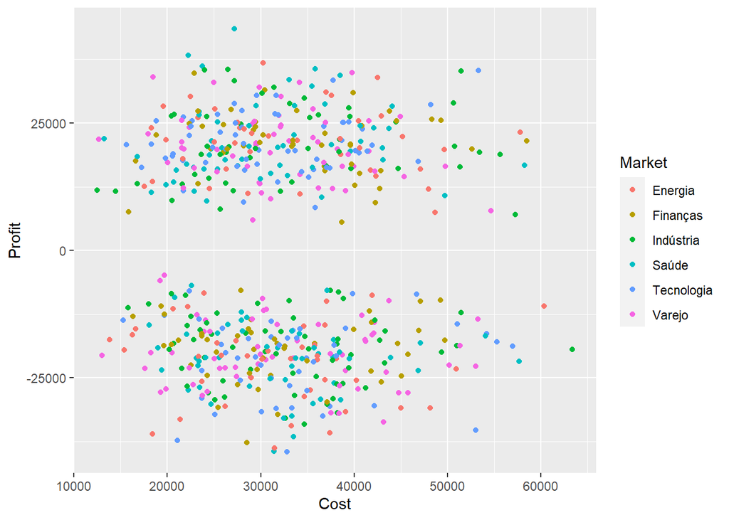

```r
dados %>% ggplot(aes(Cost, Profit, color = Market))+
  geom_point()
```

```r
library(knitr)

kable(
dados %>%
  group_by(Market) %>%
  summarise(
    Lucro_Mediano = median(Profit)
  )
, 'simple'
)
```

| Market | Lucro_Mediano |
| --- | --- |
| Energia | -8568.058 |
| Finanças | -7889.122 |
| Indústria | -9648.340 |
| Saúde | 10621.889 |
| Tecnologia | 15568.028 |
| Varejo | -5927.738 |

Tecnologia tem uma mediana de 15mil, é o melhor mercado para investir?

O custo é bem distribuido entre 20 e 40 mil, como será o lucor dos segmentos dependendo do custo do ativo?

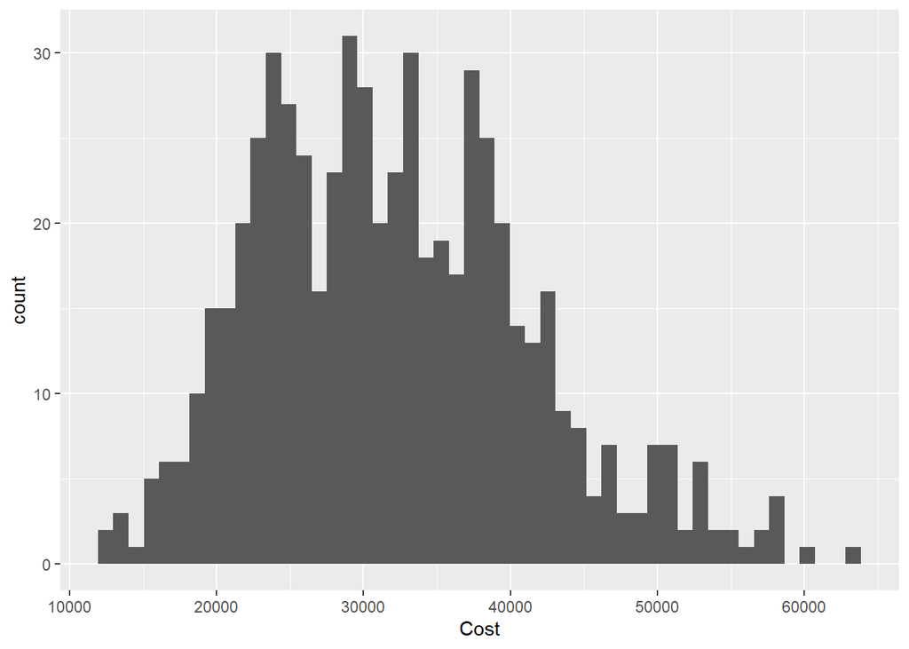

```r
dados %>% ggplot(aes(Cost)) +
  geom_histogram(bins = 50)
```

Vamos dividir os dados em duas partes, os ativos de `alto custo` e `baixo custo`

## Baixo Custo

Os ativos com Custo menor que 40mil

```r
# baixo custo
kable(
dados %>%
  filter((Cost > 40000) == FALSE) %>%
  group_by(Market) %>%
  summarise(
    count_m = n(),
    avg_profit = median(Profit),
    avg_debt = median(Debt),
    avg_cost = median(Cost),
    positive_profit_rate = round((sum(Profit > 0) / count_m) * 100, 2)
  ),
'simple'
)
```

| Market | count_m | avg_profit | avg_debt | avg_cost | positive_profit_rate |
| --- | --- | --- | --- | --- | --- |
| Energia | 62 | -13026.331 | 31250.03 | 28408.74 | 43.55 |
| Finanças | 68 | -9407.537 | 33672.47 | 28968.14 | 48.53 |
| Indústria | 90 | -9648.340 | 35792.51 | 28911.88 | 44.44 |
| Saúde | 90 | 1357.504 | 31490.88 | 28610.90 | 50.00 |
| Tecnologia | 89 | 15436.697 | 32667.25 | 29595.37 | 56.18 |
| Varejo | 90 | 11498.949 | 34849.87 | 29719.78 | 53.33 |

Percebe-se que os ativos onde a taxa de lucro (porcentagem de ativos que dão retorno financeiro) é maior que 50%, a média de lucro é positiva, apesar da média de custo ser bem parecida.

## Alto custo

Os ativos com custo maior que 40 mil

```r
kable(
dados %>%
  filter((Cost > 40000) == TRUE) %>%
  group_by(Market) %>%
  summarise(
    count_m = n(),
    avg_profit = mean(Profit),
    avg_debt = mean(Debt),
    avg_cost = mean(Cost),
    positive_profit_rate = sum(Profit > 0) / count_m
  ),
'simple'
)
```

| Market | count_m | avg_profit | avg_debt | avg_cost | positive_profit_rate |
| --- | --- | --- | --- | --- | --- |
| Energia | 18 | 5928.694 | 31793.75 | 46312.54 | 0.6666667 |
| Finanças | 23 | 1874.717 | 28821.05 | 45360.63 | 0.5217391 |
| Indústria | 18 | 1158.421 | 36620.39 | 49317.70 | 0.5000000 |
| Saúde | 14 | 6155.847 | 37303.76 | 46787.52 | 0.6428571 |
| Tecnologia | 15 | 2808.150 | 37055.52 | 47507.04 | 0.5333333 |
| Varejo | 23 | -8582.035 | 30050.15 | 45163.71 | 0.3043478 |

Percebe-se que agora, a maioria dos segmentos de mercado tem uma média de lucro positiva, exceto o Varejo, e isso também se relaciona com a taxa de lucro maior que 50%

Então a opção mais segura é investir nos ativos de baixo custo, dos segmentos de Tecnologia e Varejo.

## Como os mercados estão distribuidos entre as Regiões?

Qual é o melhor mercado em cada continente? em taxa de lucro e media de lucro

```r
kable(
dados %>%
  group_by(Market, Location) %>%
  summarise(
    profitable_rate = sum(Profit > 0) / n(),
    profit_avg = median(Profit)
  ) %>%
  arrange(desc(profitable_rate)),
'simple'
)
```

| Market | Location | profitable_rate | profit_avg |
| --- | --- | --- | --- |
| Energia | Ásia | 0.7142857 | 15293.5532 |
| Saúde | Oceania | 0.6666667 | 15982.1052 |
| Tecnologia | África | 0.6500000 | 15315.4076 |
| Saúde | América do Norte | 0.6470588 | 14704.5957 |
| Finanças | África | 0.6428571 | 14135.6523 |
| Tecnologia | Oceania | 0.6428571 | 17118.4281 |
| Varejo | Oceania | 0.6250000 | 15538.3854 |
| Indústria | América do Norte | 0.6000000 | 14073.1474 |
| Tecnologia | América do Sul | 0.5714286 | 17414.4901 |
| Tecnologia | Ásia | 0.5714286 | 13996.1719 |
| Varejo | América do Norte | 0.5652174 | 15432.0900 |
| Energia | Europa | 0.5555556 | 12565.0704 |
| Varejo | África | 0.5555556 | 9728.6120 |
| Energia | América do Sul | 0.5333333 | 7484.9876 |
| Saúde | Europa | 0.5263158 | 9642.5570 |
| Finanças | América do Sul | 0.5217391 | 7604.5783 |
| Indústria | Europa | 0.5000000 | -662.8089 |
| Tecnologia | Europa | 0.5000000 | -1328.5027 |
| Indústria | África | 0.4761905 | -8164.0570 |
| Finanças | Ásia | 0.4705882 | -12532.9027 |
| Indústria | Oceania | 0.4705882 | -8445.8915 |
| Finanças | Europa | 0.4666667 | -9748.9760 |
| Energia | Oceania | 0.4615385 | -8806.8547 |
| Finanças | América do Norte | 0.4615385 | -10925.9522 |
| Energia | América do Norte | 0.4444444 | -18099.6421 |
| Indústria | América do Sul | 0.4285714 | -8808.2722 |
| Saúde | África | 0.4285714 | -14511.5788 |
| Saúde | Ásia | 0.4285714 | -13339.5065 |
| Tecnologia | América do Norte | 0.4000000 | -13736.7311 |
| Varejo | Ásia | 0.4000000 | -14130.7063 |
| Varejo | Europa | 0.3809524 | -13465.5939 |
| Saúde | América do Sul | 0.3684211 | -17523.9489 |
| Finanças | Oceania | 0.3333333 | -17632.2866 |
| Energia | África | 0.3000000 | -14747.9399 |
| Indústria | Ásia | 0.2941176 | -15771.6072 |
| Varejo | América do Sul | 0.2500000 | -20685.1424 |

Olhando o Top 10, a melhor opção para investir é Energia na Ásia, o melhor segmento para investir é no segmento de Tecnologia, e a melhor região é Oceania. E eu ficaria longe de varejo na américa do sul.